# Tutorial

Mandy Liesch

# Packages

## Data Downloading

`geodata` : The geodata package has functions for downloading of geographic data for use in spatial analysis and mapping. The package facilitates access to climate, crops, elevation, land use, soil, species occurrence, accessibility, administrative boundaries and other data.

`tigris` : The tigris package allows for the downloading of spatial data at several geographic scales, including states and counties (shown here).

## Geoprocessing

`terra` : The [terra](https://rspatial.org/pkg/#google_vignette) package allows for methods for spatial data analysis with vector (points, lines, polygons) and raster (grid) data. This package is faster than the raster package.

`tidyterra` : The [tidyterra](https://dieghernan.github.io/tidyterra/reference/ggspatvector.html) package provides functions designed to seamlessly integrate terra objects (like SpatVector) with ggplot2.

## Display

`ggpubr` the [ggpubr](https://rpkgs.datanovia.com/ggpubr/) package provides some easy-to-use functions for creating and customizing ‘ggplot2’- based plots creating publication ready plots.

`gridExtra` the [gridExtra](https://cran.r-project.org/web/packages/gridExtra/vignettes/arrangeGrob.html) package allows for the display of plots side by side.

`tidyverse` the [tidyverse](https://www.tidyverse.org/) package is an opinionated collection of R packages designed for data science. All packages share an underlying design philosophy, grammar, and data structures.

# Vector Data

Vector Data is commonly used at its original resolution, like most traditional maps historically. This type of data comes in lines, and dots (or vertexes). These two elements are put together to create polygons, like a boundary of a lake. It can maintain data and create smooth network analysis. The vertexes need to be stored explicitly in the data, and sometimes, can require a lot of data cleaning. Whenever a file is changed, the underlying network (topology) has to be built again. In this case, we are working with polygon vector data that are the county data shapefiles.

## Shapefiles

There are 3233 county polygons and 9 data fields in the intial tigris file. However, the state vector (using State FIPS), narrows the states to ones that are in the Mississippi/Ohio River Basin. We are looking at a 12 state area that make up the bulk of these basins.

```r
#Set the option to remove scientific notation from displays
options(scipen=10000)

#Create a vector with the state FIPS that we need to extract.
states<-c("5", "17", "18", "19", "21", "22", "27","28",  "29", "39", "47", "55")

#Use the tigris package, and get the counties extracted by the state we specificied
#in the states vector
counties_raw <- tigris::counties(states,
  #add the county boundaries
  cb = TRUE,
  #specify the resolution (we don't need the highest one)
  resolution = "500k",
  #Pick the year the county files are extracted
  year = 2019,
  #specify the data type
  class = "sf"
)
```

```r
#Check the metadata information
counties_raw
```

```
## Simple feature collection with 1091 features and 9 fields
## Geometry type: MULTIPOLYGON
## Dimension:     XY
## Bounding box:  xmin: -97.23921 ymin: 28.92861 xmax: -80.51869 ymax: 49.38436
## Geodetic CRS:  NAD83
## First 10 features:
##    STATEFP COUNTYFP COUNTYNS       AFFGEOID GEOID         NAME LSAD      ALAND
## 26      05      119 00069177 0500000US05119 05119      Pulaski   06 1964339922
## 27      05      075 00066865 0500000US05075 05075     Lawrence   06 1521913730
## 28      05      093 00069899 0500000US05093 05093  Mississippi   06 2332481583
## 29      05      001 00063755 0500000US05001 05001     Arkansas   06 2561013146
## 30      05      081 00066874 0500000US05081 05081 Little River   06 1378511385
## 31      05      121 00069178 0500000US05121 05121     Randolph   06 1689251373
## 32      05      067 00066861 0500000US05067 05067      Jackson   06 1641629489
## 33      05      103 00069170 0500000US05103 05103     Ouachita   06 1897898727
## 34      05      107 00069172 0500000US05107 05107     Phillips   06 1801669169
## 35      05      003 00063756 0500000US05003 05003       Ashley   06 2396668938
##       AWATER                       geometry
## 26 126230012 MULTIPOLYGON (((-92.75498 3...
## 27  12286149 MULTIPOLYGON (((-91.35729 3...
## 28  49826387 MULTIPOLYGON (((-90.2888 35...
## 29 116378934 MULTIPOLYGON (((-91.7101 34...
## 30  84225310 MULTIPOLYGON (((-94.48558 3...
## 31   9889900 MULTIPOLYGON (((-91.40714 3...
## 32  19623387 MULTIPOLYGON (((-91.58319 3...
## 33  18050436 MULTIPOLYGON (((-93.11636 3...
## 34  82139041 MULTIPOLYGON (((-91.11748 3...
## 35  39291076 MULTIPOLYGON (((-92.1436 33...
```

The polygon file has several important attributes, as well as columns of data associated with each county file (shapefile). There are 1091 counties, with 9 different geographic fields.

Bounding box limits the geographic area. The Geodetic CRS is very important information when we are dealing with spatial data. IF you are combining or layering information, this value must be the same in both sources, or projections will not line up. The NAD83 is very common for US Datasets.

Columns include the State FIP value and the county FIP values, as well as the combined GEOID, County Name, Area of Land, water and the Geometry attributes. We do not need the extra values, so we can remove all of the extra columns, except for GEOID and the county NAME.

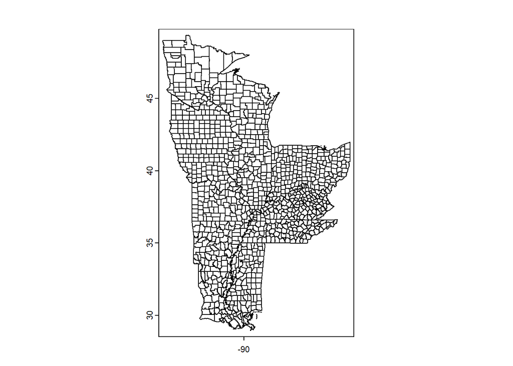

```r
#Select the columns needed for geographic data
counties <- counties_raw %>%
  #Choosing the GEOID to pair with datasets and the county Names
  select(GEOID, NAME)

#Convert data file into a spatVector
counties<- vect(counties)

#plot the counties to check the geographic area
plot(counties)
```

When you use the plot function in base R, it will plot every column as a unique plot, in this case, we will get 2 of these plots. Changing the values into a spatvector using the Terra package shows only one shapefile, and removes the geometries as a column. This also allows the setup to use values in ggplot at a later time.

## Ancillary Data

Most of these shapefiles can be merged with datafiles and spreadsheets to expand and visualize anything with data. A majority of this federally based data is classified by State code (two numbers) and county code (three numbers). These are combined together to create a GEOID (or FIPS). For example, the State of Wisconsin has a state code of 55, and each county has its own number, Outagamie County, WI, for example, is county 087, giving it an idenity of 55087.

Almost all federal agencies have large respositories of data that anyone can access, via downloads of spreadsheet files (or .csv) that can be used for mapping with shapefiles.

[Atlas of Rural Towns (USDA ERS)](https://www.ers.usda.gov/data-products/atlas-of-rural-and-small-town-america): Focused on statistical metrics for Rural America, including People, Jobs, Classification, Incomes and Veteran based data.

[USDA ERS Data](https://www.ers.usda.gov/data-products): ERS has a huge amount of data covering key information about the farm and food sectors, including agricultural markets and trade, farming and farm income, food prices and consumption, food security and nutrition assistance, rural economies, and the interaction of agriculture and natural resources.

[CDC Wonder](https://wonder.cdc.gov/): It provides access to a wide array of public health data for researchers, public health professionals, and the general public. CDC WONDER offers various online databases containing information on births, deaths, cancer, STDs, TB, and more.

[National Agricultural Statistics Service](https://quickstats.nass.usda.gov/): Conducts hundreds of surveys every year and prepares reports covering virtually every aspect of U.S. agriculture. This includes the Census of Agriculture, published every 5 years. Production and supplies of food and fiber, prices paid and received by farmers, farm labor and wages, farm finances, chemical use, and changes in the demographics of U.S. producers are only a few examples.

[Census Bureau](https://www.census.gov/data.html): A huge source of data, including the American Community Surveys, and the census taken every 10 years. If you need data on demographics, economics, and all things socio-demographic.

[Bureau of Labor Statistics](https://www.bls.gov/data/): It is the principal fact-finding agency in the broad field of labor economics and statistics and serves as part of the U.S. Federal Statistical System. BLS collects, calculates, analyzes, and publishes data essential to the public, employers, researchers, and government organizations.

## Datafile

For these shapefiles, we are utilizing a .csv file that was curated from the NASS database from the 2017 Agricultural Census for states on the Mississippi River Basin.

```r
#Load the data frame
NASS2017<-read.csv("NASS2017_Snapshot.csv")

#Make sure that all columns have 5 numbers
NASS2017$FIPS<-sprintf("%05d", NASS2017$FIPS)

#Check example output
head(NASS2017)
```

```
##    FIPS MARKET_VALUE Per_Crop_Sales Per_Grain_Mark_Val Per_Cotton_Mark_Val
## 1 05001    214280000          99.61              99.46                0.00
## 2 05003     70196000          90.38              62.08               20.91
## 3 05005     31762000           2.75               0.00                0.00
## 4 05007    593372000           1.27               0.26                0.00
## 5 05009    164017000           1.90               0.33                0.00
## 6 05011     42083000          15.81               0.00                0.00
##   Per_Other_Crop_Mark_Val Per_Veg_Sale_Mkt_Val Per_Fruit_Sales_Mkt_Val
## 1                    0.04                 0.00                    0.03
## 2                    0.31                 6.06                    0.34
## 3                    1.99                 0.10                    0.33
## 4                    0.56                 0.04                    0.06
## 5                    1.37                 0.05                    0.11
## 6                    0.85                14.89                    0.04
##   Per_Nursery_Sales_Val Per_Cut_Tree_Sales_Val Per_Ani_Sales_Mark_Val
```

[output cut: 34 more lines]

There are 1,090 counties in this area, and 27 columns of data involving crop and agricultural production data.

*FIPS:* Federal code identifying counties

*Market_Value:* Total Agricultural Market Value in the County in dollars

*Per_Crop_sales:* Percentage of Agricultural Income Generated by Crop Production

*Per_Grain_Mark_Val:* Percentage of Agricultural Income Generated by grain crops (Corn, soybean, etc.)

*Per_Cotton_Mark_Val:* Percentage of Agricultural Income Generated by cotton

*Per_Other_Crop_Mark_Val:* Percentage of Agricultural Income Generated by other crops (like oil crops, hops, etc)

*Per_Veg_Sale_Mkt_Val:* Percentage of Agricultural Income Generated by vegetables (carrots, cabbage, etc)

*Per_Fruit_Sales_Mkt_Val:* Percentage of Agricultural Income Generated by fruits (melons, cranberries, blueberries, etc)

*Per_Nursery_Sales_Val:* Percentage of Agricultural Income Generated by nursery crops

*Per_Cut_Tree_Sales_Val:* Percentage of Agricultural Income Generated by cut trees

*Per_Ani_Sales_Mark_Val:* Percentage of Agricultural Income Generated by Animal Production

*Per_Poul_Sales_Mark_Val:* Percentage of Agricultural Income Generated by Poultry Production (Turkey, Broilers, Eggs, etc.)

*Per_Milk_Sales_Mrk_Val:* Percentage of Agricultural Income Generated by Milk and Milk products

*Per_Cattle_Sales_Mrk_Val:* Percentage of Agricultural Income Generated by live cattle sales

*Per_Hog_Sales_Mrk_Val:* Percentage of Agricultural Income Generated by hog sales

*Per_Sheep_Sales_Mrk_Val:* Percentage of Agricultural Income Generated by sheep sales

*PER_AQ_SALES:* Percentage of Agricultural Income Generated by aquaculture sales

*PER_EQ_SALES:* Percentage of Agricultural Income Generated by equine sales

*PER_SP_AN_SALES:* Percentage of Agricultural Income Generated by other animal sales

*Per_Cropland_Manure:* Percentage of Agricultural Land with Manure application

*Cattle_Operations:* Number of Cattle Operations in the county

*Milk_Operations:* Number of Milk Operations in the county

*Poul_Total_Oper:* Number of Poultry Operations in the county

*Hog_Oper:* Number of Hog Operations in the county

*TOT_SHEEP_Oper:* Number of sheep Operations in the county

*EQUI_OPER:* Number of horse Operations in the county

*TOT_AQUA_OPER:* Number of Aquaculture Operations in the county

In order to visualize this data, we need to merge this database with the shapefile.

```r
#the counties data and Agricultural Statistics file
ag_data<-merge(counties, NASS2017,
               #The Counties files is called GEOID
               by.x='GEOID',
               # The NASS file is merged from the FIPS column
               by.y='FIPS')

#Check the data
ag_data
```

```
##  class       : SpatVector
##  geometry    : polygons
##  dimensions  : 1090, 28  (geometries, attributes)
##  extent      : -97.23921, -80.51869, 28.92861, 49.38436  (xmin, xmax, ymin, ymax)
##  coord. ref. : lon/lat NAD83 (EPSG:4269)
##  names       : GEOID        NAME MARKET_VALUE Per_Crop_Sales Per_Grain_Mark_Val
##  type        : <chr>       <chr>        <int>          <num>              <num>
##  values      : 05119     Pulaski     20276000           81.1              73.51
##                05075    Lawrence    150597000          66.26              63.46
##                05093 Mississippi    300927000          99.97              70.07
##  Per_Cotton_Mark_Val Per_Other_Crop_Mark_Val Per_Veg_Sale_Mkt_Val
##                <num>                   <num>                <num>
##                    0                    1.91                  1.1
##                    0                    2.79                 0.01
##                24.93                     4.2                 0.38
##  Per_Fruit_Sales_Mkt_Val Per_Nursery_Sales_Val (and 18 more)
##                    <num>                 <num>
##                     3.12                  1.29
##                     0.01                     0
##                     0.04                  0.35
```

The file is now converted into a Spatvector, in the NAD83 reference system.

### Create a Map

Use the Geom Spatvector function to graph the shapefile. The resulting file should be a blank shapefile. We need to add parameters to the ggplots to actually make meaningful maps.

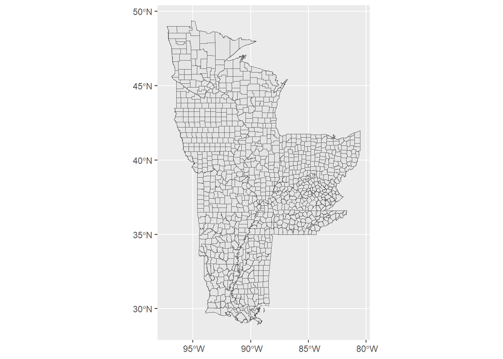

```r
#cue up a ggplot
ggplot(ag_data) +
  #utilize the geom_spatvector in tidyterra
  geom_spatvector()
```

Add a column to display using the AES fill option

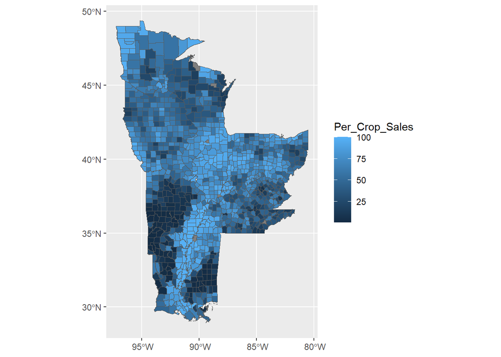

```r
crop_plot<-ggplot() +
  #using the dataset, the fill = column can be changed to any of the above columns
  #to display another variable
  geom_spatvector(data=ag_data,
                  #The fill value is the parameter that AES visualizes
                  aes(fill = Per_Crop_Sales))

#Check the plot
crop_plot
```

Get a new color scheme. [Color schemes](https://ggplot2-book.org/scales-colour.html) can be flexible, and displayed in many different ways. There are a million different color options, but the Viridis Pallette are designed to be perceptually uniform in both colour and when reduced to black and white, and to be perceptible to people with various forms of colour blindness. The data we are looking at today is continuous, not categorical, which is where the c comes from in the scale fill. There are 8 different options in the Viridis pallette.

```r
#Look at the different color options
?scales::pal_viridis
```

```
## starting httpd help server ... done
```

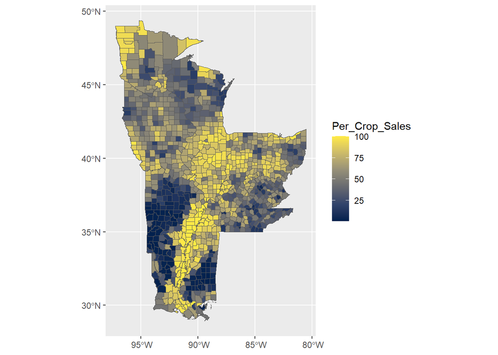

```r
#Create the ggplot
crop_plot<-ggplot() +
  #using the dataset, the fill = column can be changed to any of the above columns
  #to display another variable. I am using the Percent Crop Sales here
  geom_spatvector(data=ag_data, aes(fill = Per_Crop_Sales)) +
  #Change the color scale using the option
    scale_fill_viridis_c(option = "cividis")

#Check the plot
crop_plot
```

Customize the legend name by adding a name function to the scale fill option.

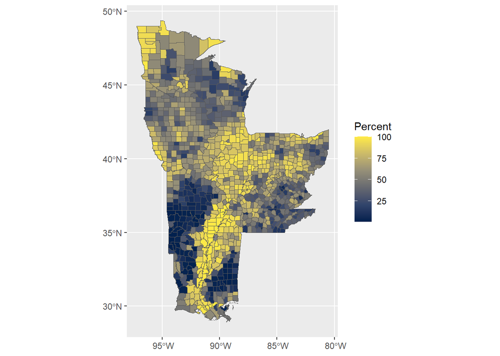

```r
#Plot the plot with a Legend Name
crop_plot<-ggplot() +
  #using the dataset, the fill = column can be changed to any of the above columns
  #to display another variable
  geom_spatvector(data=ag_data, aes(fill = Per_Crop_Sales)) +
  #Change the color scale using his options
    scale_fill_viridis_c(option = "cividis",
                         #Customize the Name of the Legend
                         name = "Percent")

#Check the Plot
crop_plot
```

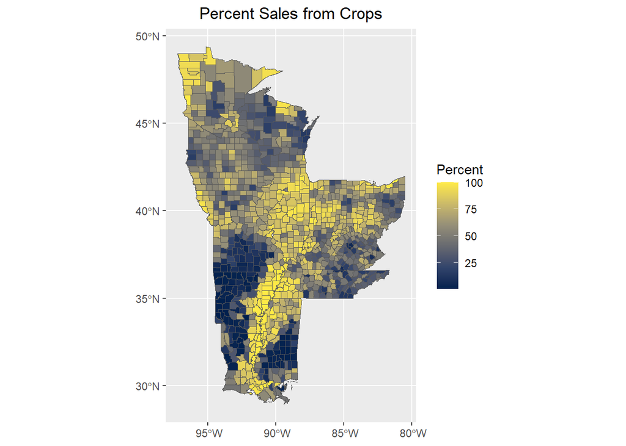

```r
#Look at the different color options
crop_plot<-ggplot() +
  #using the dataset, the fill = column can be changed to any of the above columns
  #to display another variable
  geom_spatvector(data=ag_data, aes(fill = Per_Crop_Sales)) +
  #Change the color scale using his options
    scale_fill_viridis_c(option = "cividis",
                         #Customize the Name of the Legend
                         name = "Percent") +
  #Add a title
  ggtitle("Percent Sales from Crops") +
  #Use the ggplot theme function and center it using the element text
  theme(plot.title = element_text(hjust=0.5),
        #And put the legend in the bottom
        legend.position = "right")

#Check the plot
crop_plot
```

### Your Turn!

Change the display variable to a different column, and then change the color and name! You can scroll up to get the variable names and definitions, or you can use the names(ag_data) to get a list of all of the variables

```r
#Look at the legend names
names(ag_data)
```

```
##  [1] "GEOID"                    "NAME"
##  [3] "MARKET_VALUE"             "Per_Crop_Sales"
##  [5] "Per_Grain_Mark_Val"       "Per_Cotton_Mark_Val"
##  [7] "Per_Other_Crop_Mark_Val"  "Per_Veg_Sale_Mkt_Val"
##  [9] "Per_Fruit_Sales_Mkt_Val"  "Per_Nursery_Sales_Val"
## [11] "Per_Cut_Tree_Sales_Val"   "Per_Ani_Sales_Mark_Val"
## [13] "Per_Poul_Sales_Mark_Val"  "Per_Milk_Sales_Mrk_Val"
## [15] "Per_Cattle_Sales_Mrk_Val" "Per_Hog_Sales_Mrk_Val"
## [17] "Per_Sheep_Sales_Mrk_Val"  "PER_AQ_SALES"
## [19] "PER_EQ_SALES"             "PER_SP_AN_SALES"
## [21] "Per_Cropland_Manure"      "Cattle_Operations"
## [23] "Milk_Operations"          "Poul_Total_Oper"
## [25] "Hog_Oper"                 "TOT_SHEEP_Oper"
## [27] "EQUI_OPER"                "TOT_AQUA_OPER"
```

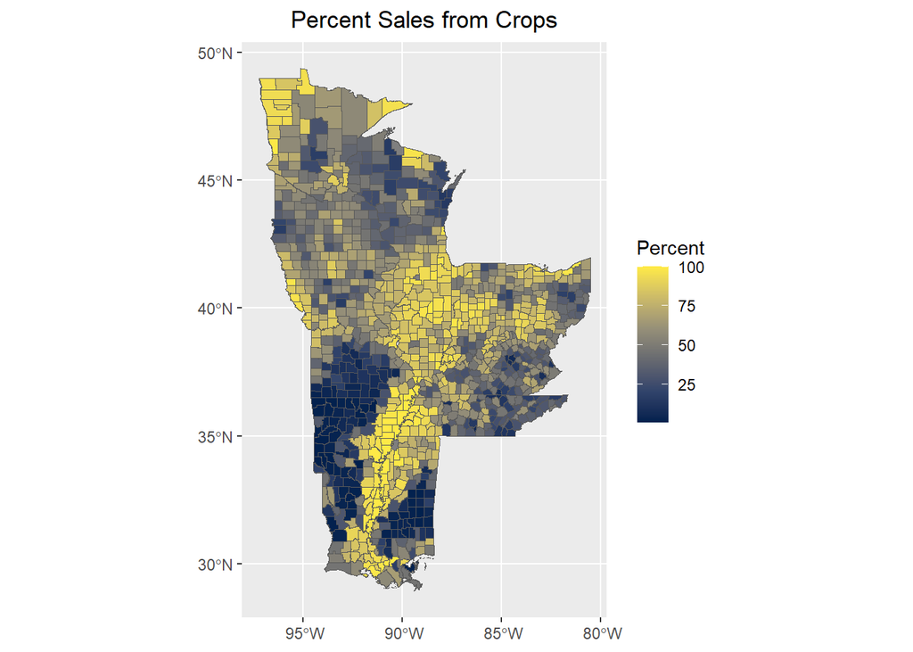

```r
#Look at the different color options
?scales::pal_viridis


plot2<-ggplot() +
  #using the dataset, the fill = column can be changed to any of the above columns
  #to display another variable
  geom_spatvector(data=ag_data, aes(fill = Per_Crop_Sales)) +
  #Change the color scale using this options
    scale_fill_viridis_c(option = "cividis",
                         #Customize the Name of the Legend
                         name = "Percent")  +
  #Customize the title based on your data
  ggtitle("Percent Sales from Crops") +
  #You can put the legend in the center here, or leave it on the left (delete element text)
  #or right ((hjust =1))
  theme(plot.title = element_text(hjust=0.5),
        #Feel free to move the legend away from the bottom, or hit ?theme for other options
        legend.position = "right")

plot2
```

### Side by Side Plots

This using the gridExtra package, we can arrange graphs to be side by side into rows or columns. This data is better suited for columns. So we can use the grid.arrange to plot several plots into the same area.

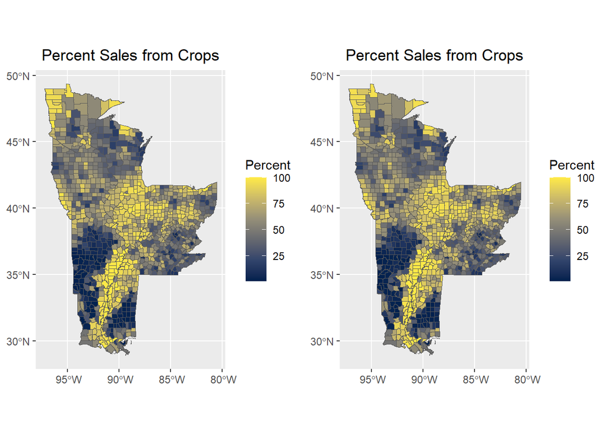

```r
#Using the grid arrange, we can put the two plots together side by side
grid.arrange(crop_plot, plot2, ncol=2)
```

### Side by Side Plots With the Same Legend

If you have data like we do in this NASS dataset that is mostly in percentage (though, we have some count or dollar data). You can extract the legend and turn it into a ggplot figure

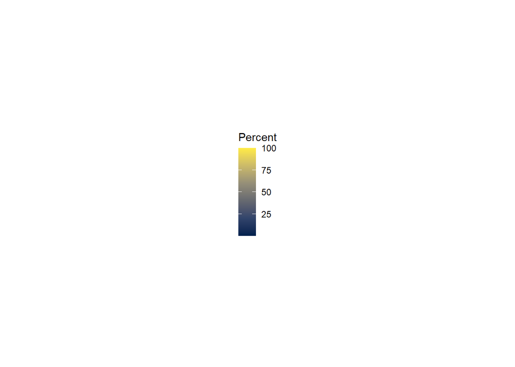

```r
# Extract the legend. Returns a gtable
leg <- get_legend(crop_plot)

# Convert to a ggplot and print
as_ggplot(leg)
```

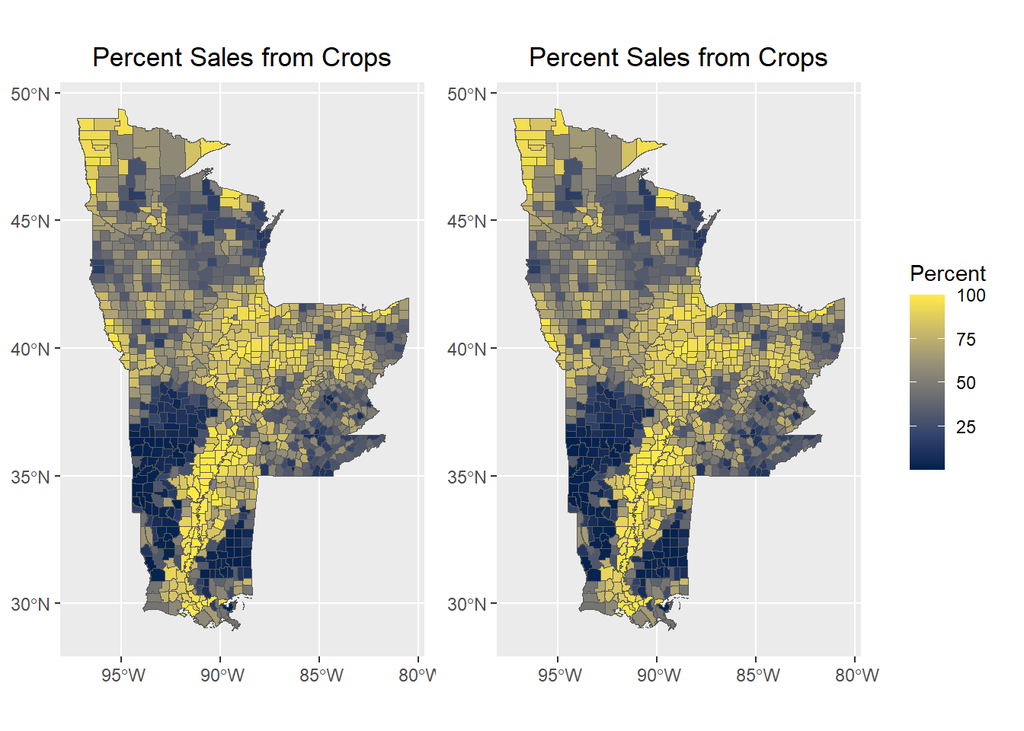

```r
#Remove the legends from the old plots
crop_plot <- crop_plot + theme(legend.position="none")

#Remove the legends from the old plots
plot2 <- plot2 + theme(legend.position="none")

#Create a file with two different plots and the legend into three columns
grid.arrange(crop_plot, plot2, leg, ncol=3,
             #Customize the widths to allow
             widths=c(2.3, 2.3, 0.8))
```

### Vector Calculations

You can utilize the data existing in the data frame to create new columns for display as well! We have the total market value, and can use this to multiply by the percent sales to get total market values in the Poultry Industry, and then divide by total producers to get total farm size too!

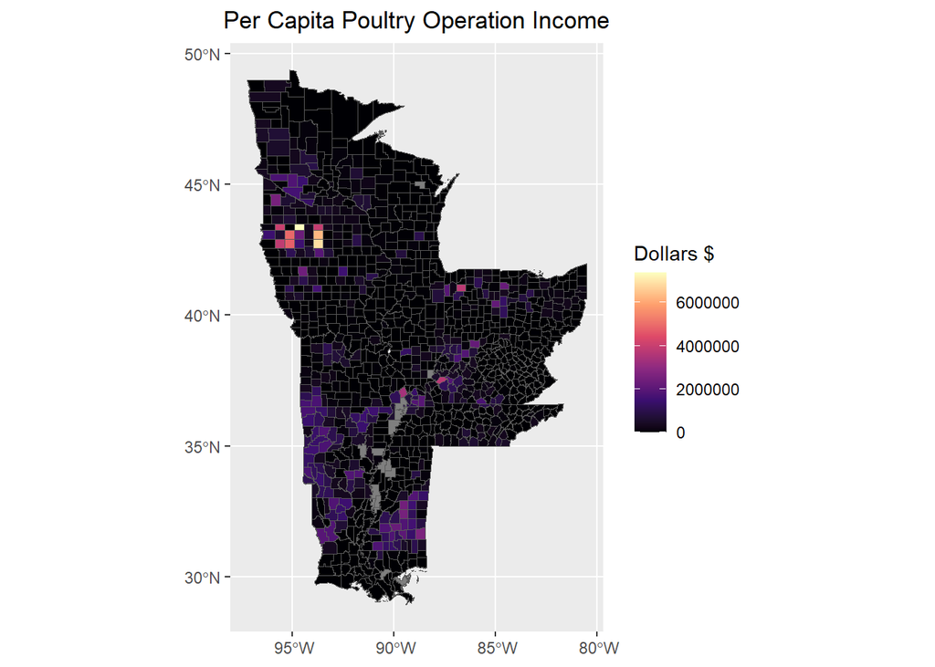

```r
#Calculate the amount that poultry operations make per operator
ag_data$Poultry_Per_Capita = (ag_data$MARKET_VALUE * (ag_data$Per_Poul_Sales_Mark_Val/100)) / ag_data$Poul_Total_Oper

Poultry_Per_Capita<-ggplot() +
  #using the dataset, the fill = column can be changed to any of the above columns
  #to display another variable
  geom_spatvector(data=ag_data, aes(fill = Poultry_Per_Capita)) +
  #Change the color scale using this options
    scale_fill_viridis_c(option = "magma",
                         #Customize the Name of the Legend
                         name = "Dollars $") +
  #Customize the title based on your data
  ggtitle("Per Capita Poultry Operation Income") +
  #You can put the legend in the center here, or leave it on the left (delete element text)
  #or right ((hjust =1))
  theme(plot.title = element_text(hjust=0.5),
        #Feel free to move the legend away from the bottom, or hit ?theme for other options
        legend.position = "right")

Poultry_Per_Capita
```

# Raster Data

Raster data represents information as a grid of tiny squares called pixels. They are super common for use in spatially explicit datasets. Each cell has a position and color and is stored in a matrix. Each layer of maps show one attribute, and they are ideally suited for modeling and analysis. Data can be discrete (like land use), or continuous (like elevation), and it can handle both types very easily. The cell size determines resolution for the data. Size of rasters are variable, and it is difficult to establish linear relationships (they get very pixellated). They only can represent one value at a time, and the data can be very large over time and areas. Data also needs to be generalized or interpolated, resulting in data losses and outputs.

## Raster Processing

The geodata package is a very diverse package that allows for the deployment of many different types of earth science data.

```r
# Read the .tif  as a SpatRaster
SG_2020<-soil_world_vsi(var="ocs", depth=30)
```

```r
#Project the ag_data from the NAD 83 into the SG_2020 IGH Dataset project(from, to)
ag_data1<-project(ag_data, SG_2020)

#The crop function cuts the FAO glosis map to the ag_data1 area. Mask =  True cuts away the excess.

MS_Area<-crop(SG_2020, ag_data1,
              #Remove this function and see what it does!
              mask=TRUE)

MS_Area
```

```
## <SpatRaster> resampled to 501155 cells.
```

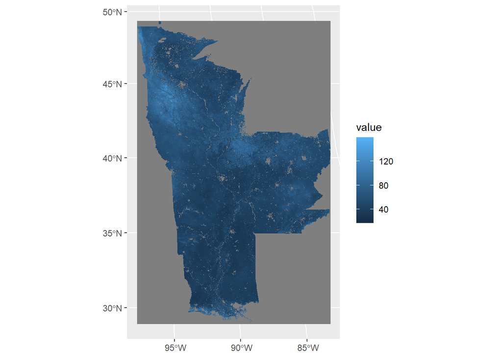

```r
ggplot() +
  geom_spatraster(data=MS_Area)
```

```
## <SpatRaster> resampled to 501155 cells.
```

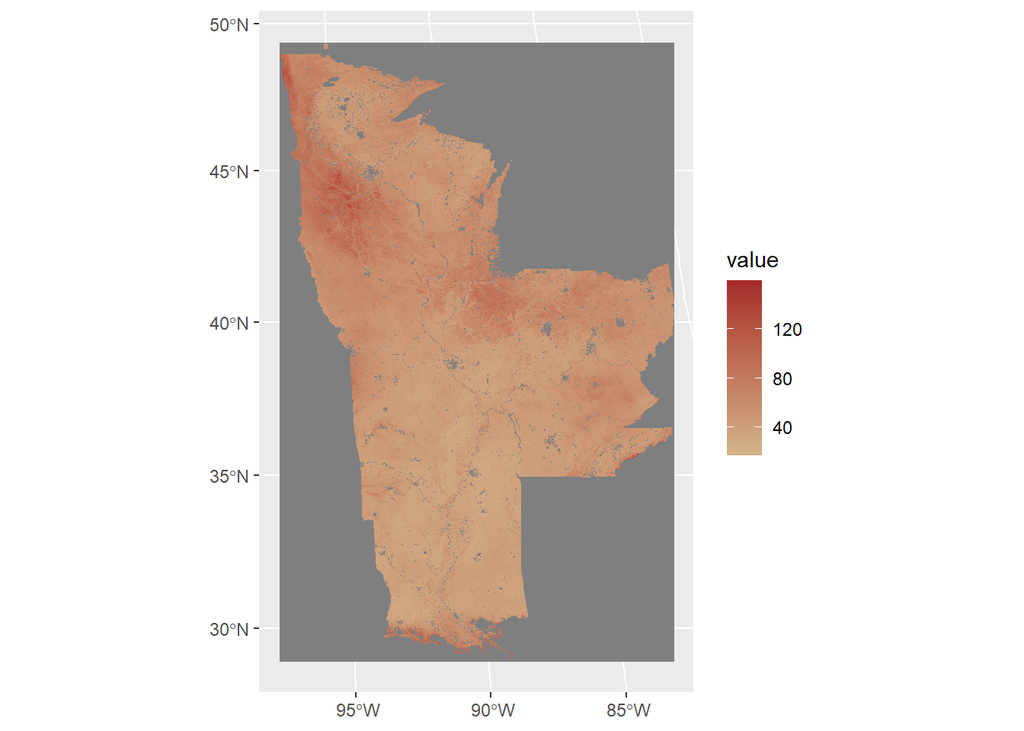

```r
ggplot() +
  geom_spatraster(data=MS_Area) +
  scale_fill_gradient(low = "tan", high = "brown")
```

Change the visual scale using the clamp variable. Everything over the value that you set will display at the value you specify. This code also adds the legend name.

```
## <SpatRaster> resampled to 501155 cells.
```

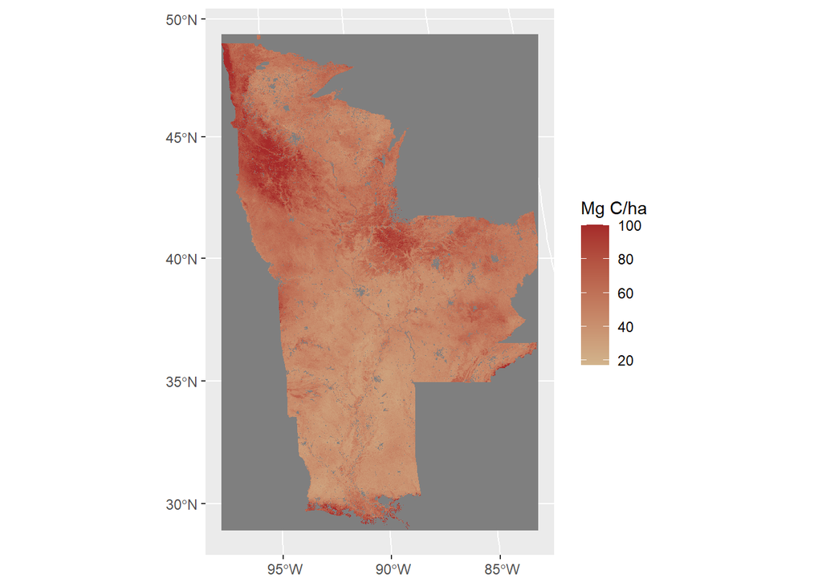

```r
#We are setting 100 Mg C/ha as our upper display limit. Change this value up and down
#and decide if you have a preference
clamped_raster <- clamp(MS_Area, upper = 100,
                        #values If FALSE values outside the clamping range become NA,
                        #if TRUE, they get the extreme values. See what it looks like if  Values=False
                        values = TRUE)

ggplot() +
  #change the raster value to the clamped raster
  geom_spatraster(data=clamped_raster) +
  #keep the same color gradient
  scale_fill_gradient(low = "tan", high = "brown",
                      #add the title to the legend as well
                      name = "Mg C/ha")
```

Add the county shapefile on top so we have some visual boundaries to look at, and add a title and some themes (described above) to the plot, and put the legend at the bottom of the plot.

```r
#Create the SOC Map
SOC_Map<-ggplot() +
  #Use the clamped raster
  geom_spatraster(data=clamped_raster) +
  #keep the same color gradient
  scale_fill_gradient(low = "tan", high = "brown",
                      #Add the units to the legend
                      name = "Mg C/ha",
                      #make the NA values transparent, rather than grey for clarity
                      na.value = "transparent") +
  #Add the reprojected spatvector file using a fill value of NA, so you can see the underlying raster values
  geom_spatvector(data=ag_data1, fill=NA) +
  #Add a title
  ggtitle("Total Soil Organic Carbon") +
  #center the title and put the legend on the bottom.
  theme(plot.title = element_text(hjust=0.5), legend.position = "bottom")
```

```
## <SpatRaster> resampled to 501155 cells.
```

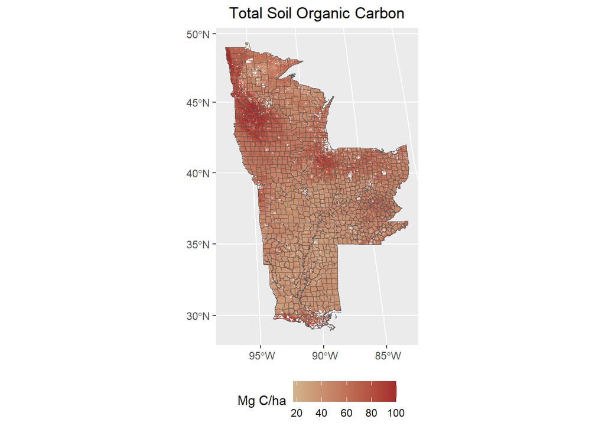

```r
#check the map
SOC_Map
```

Use what we learned above to plot a side by side of the raster and vector data in the same figure

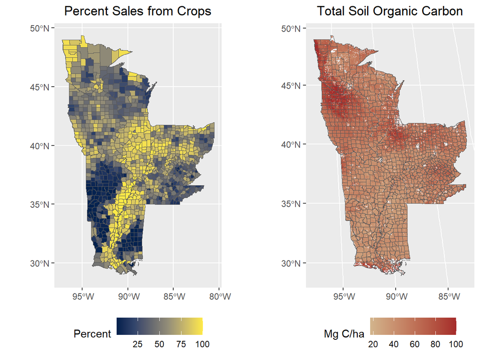

```r
#Move the crop_plot legend to the bottom so it matches the total SOC plot
crop_plot <- crop_plot + theme(legend.position="bottom")

#Use two upright columns to map the figures together. Try changing ncol to nrow to see the difference.
grid.arrange(crop_plot, SOC_Map, ncol=2)
```

## Your Turn

1. Pull the soil clay from the top 5 cm map (in g/kg) from the geodata package: Hint, ?soil_world_vsi if you need more information.
2. Check the file Resolution and Projection, are they the same as the clamped_raster we used? What could the different resolutions mean?
3. Project the data to the existing dataset (if need be)
4. crop and mask the soil clay raster to the Mississippi river area
5. Customize and label your raster plot
6. plot it next to the SOC carbon map above